Lake Name: Lake Rippowam

Lake acreage: 30.9

County: WESTCHESTER

PWLID: 1302-0141

Waterbody Classification: B

Coordinates: 41.300098,-73.562798

Is this waterbody a public water supply: No

Are there DOH desingated beaches on this waterbody: No

Open Water Indicators

2018 Sampling Results

Seasonal Change

04-09

05-14

06-11

06-24

07-08

07-22

07-26

08-05

08-19

09-03

09-16

10-14

11-11

Clarity (m)

2.75

3.00

3.05

3.15

2.65

1.70

1.85

2.15

1.60

2.25

1.55

1.55

1.75

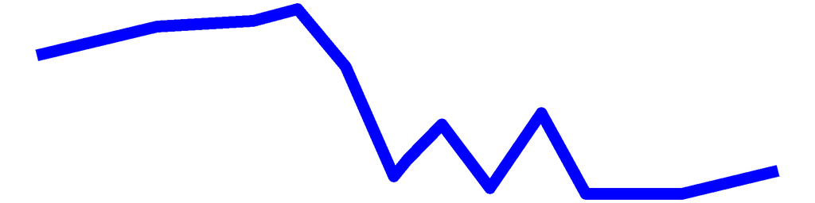

Surface TP (mg/L)

0.02

0.02

0.02

0.02

0.01

0.02

0.04

0.03

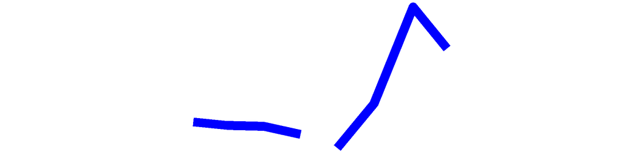

Surface TDP (mg/L)

0.01

0.01

0.00

0.01

0.01

0.01

0.01

0.01

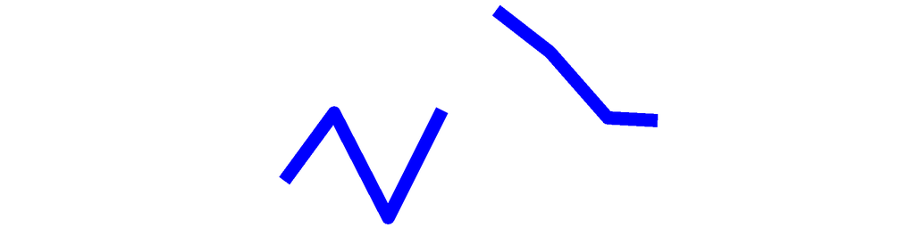

Deep TP (mg/L)

0.09

0.11

0.09

0.11

0.11

0.09

0.08

0.03

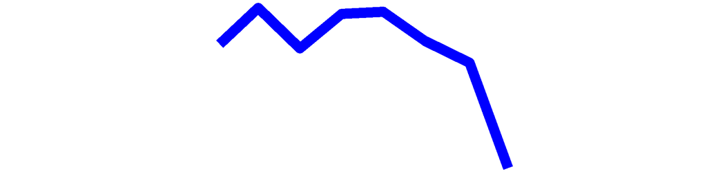

Deep TDP (mg/L)

0.01

0.03

0.04

0.03

0.01

0.04

0.02

0.01

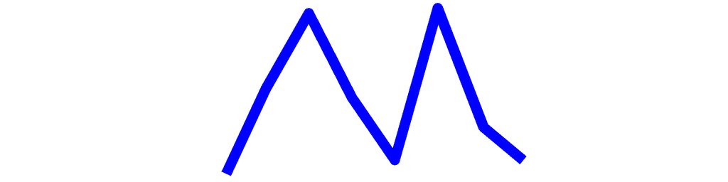

TN (mg/L)

0.52

0.58

0.64

0.61

0.66

0.59

0.64

0.73

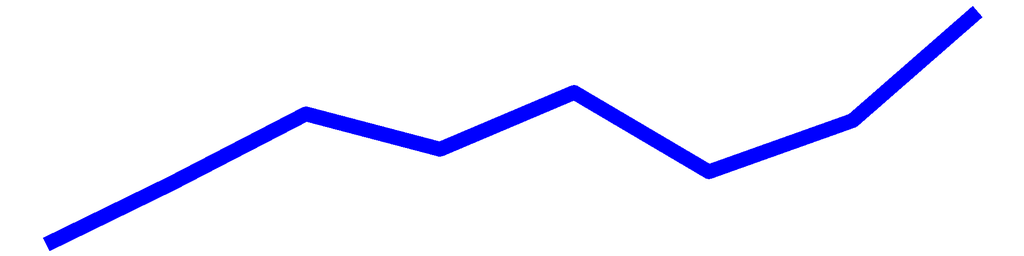

TDN (mg/L)

0.52

0.60

0.54

0.56

0.55

0.45

0.47

0.70

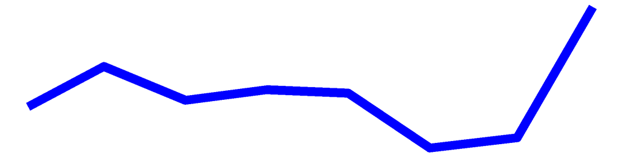

TN:TP

29.83

34.32

38.48

40.46

53.41

27.86

15.72

22.83

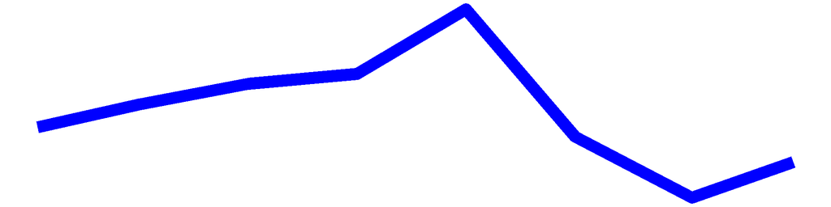

Surface NH3 (mg/L)

0.05

0.01

0.03

0.06

0.06

0.02

0.07

0.00

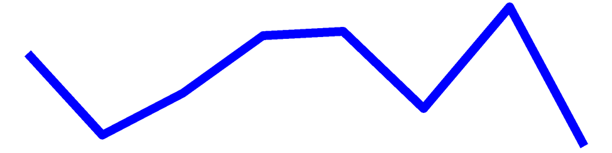

Deep NH3 (mg/L)

0.12

0.02

0.00

0.20

0.46

0.98

1.66

2.08

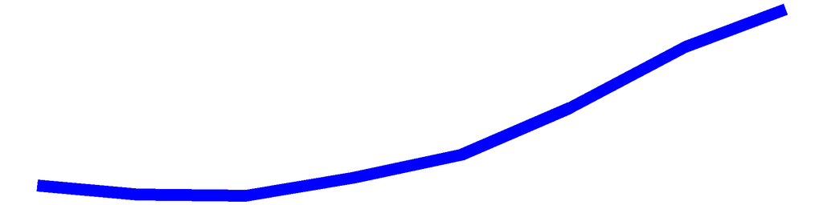

Chl.a (ug/L)

3.30

4.50

8.60

13.70

13.90

16.80

28.20

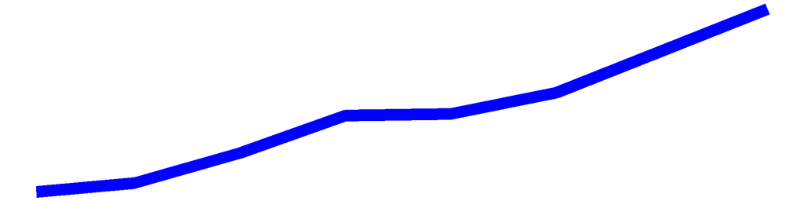

pH

7.92

7.67

8.12

7.91

7.84

7.34

8.33

7.55

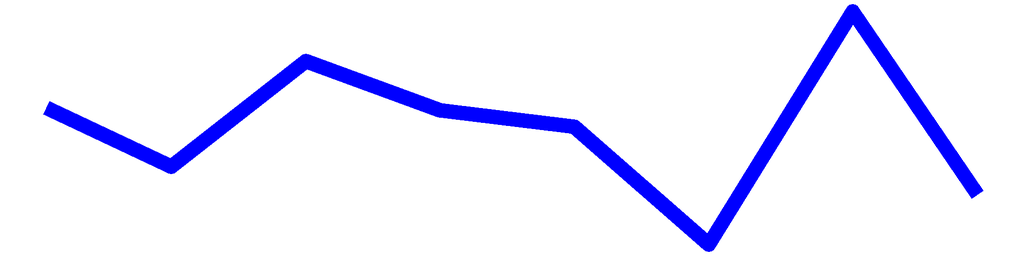

Cond (umho/cm)

80.10

130.20

238.50

248.50

239.50

228.80

238.60

221.50

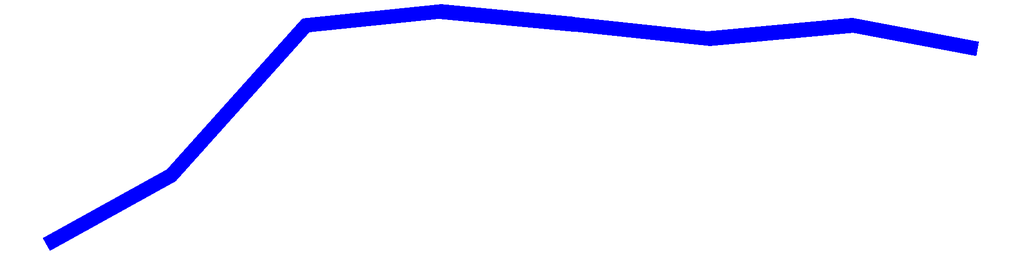

Surface Calcium (mg/L)

Bottom Calcium (mg/L)

Surface Chloride (mg/L)

37.30

39.10

Bottom Chloride (mg/L)

Upper Temp (degC)

7.00

18.00

22.00

24.00

26.80

25.60

26.00

27.50

26.80

26.20

23.40

17.90

9.70

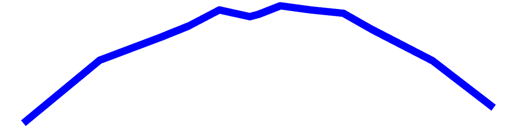

Deep Temp (degC)

7.00

11.00

12.00

15.00

17.20

16.30

19.00

17.30

18.40

20.10

17.70

9.50

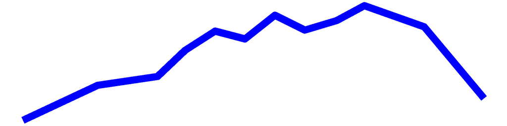

FP BG Chl.a (ug/L)

10.68

10.06

14.52

23.83

26.56

27.98

39.29

45.15

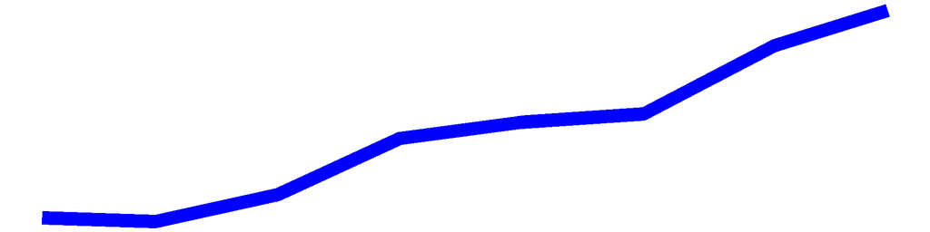

## Lake Rippowam – Sampling Season Results

### HABs Status

#### Open Water Algae

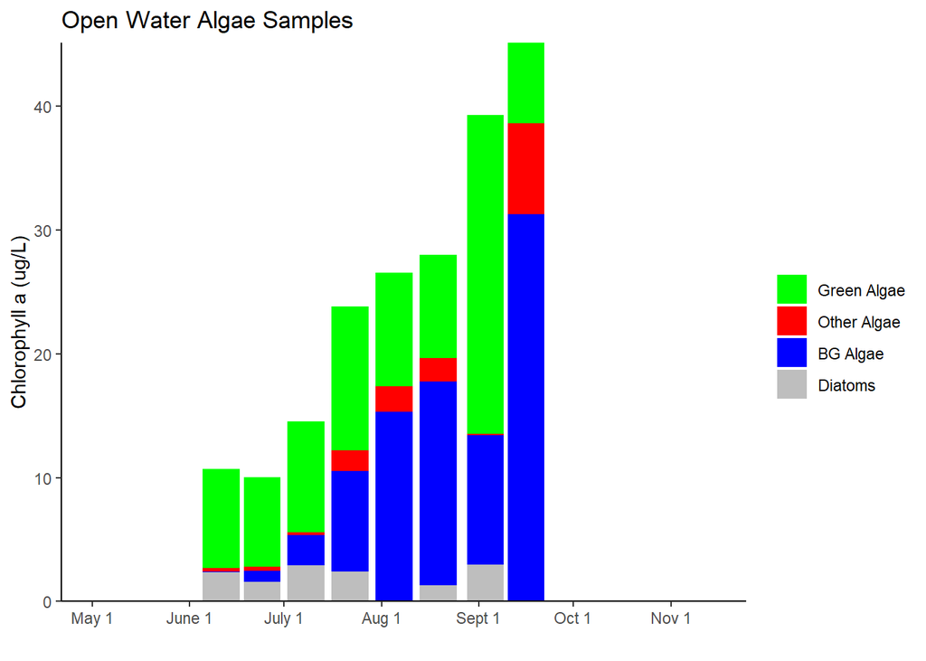

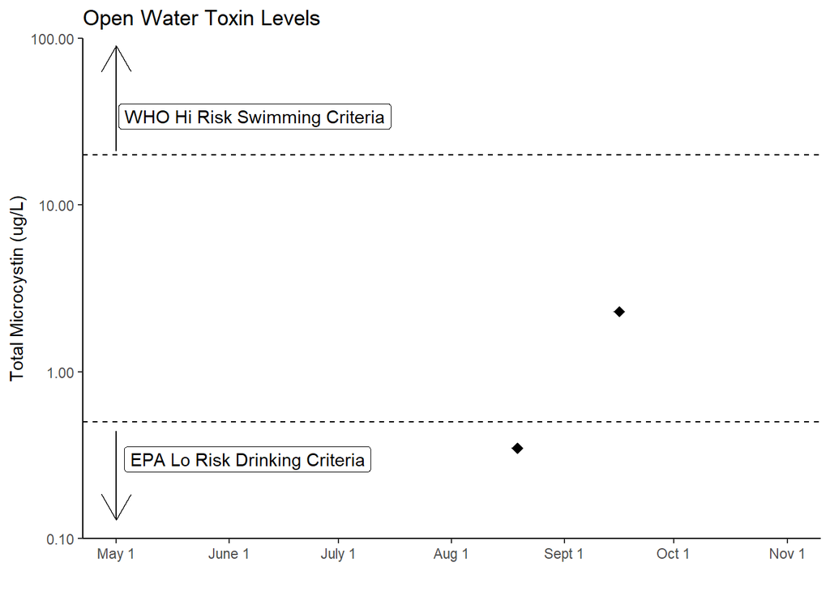

#### Shoreline Algae

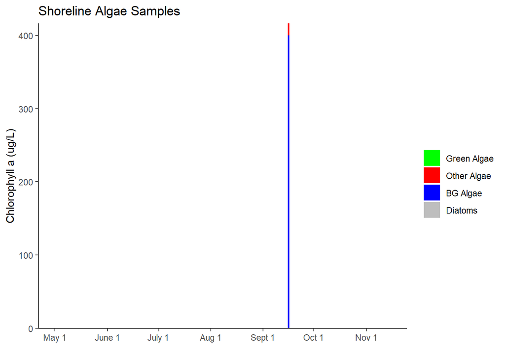

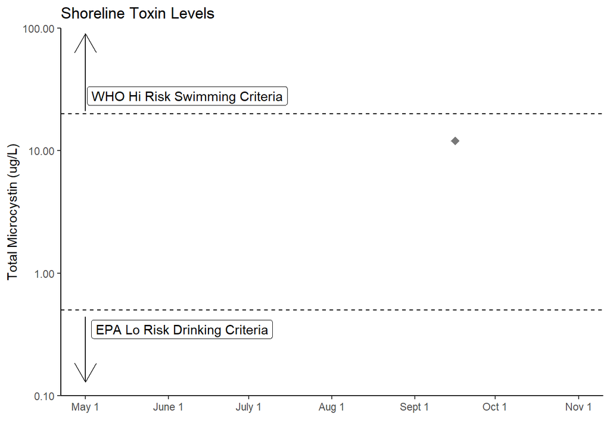

## Lake Rippowam Long-Term Trend Analysis

#### Clarity

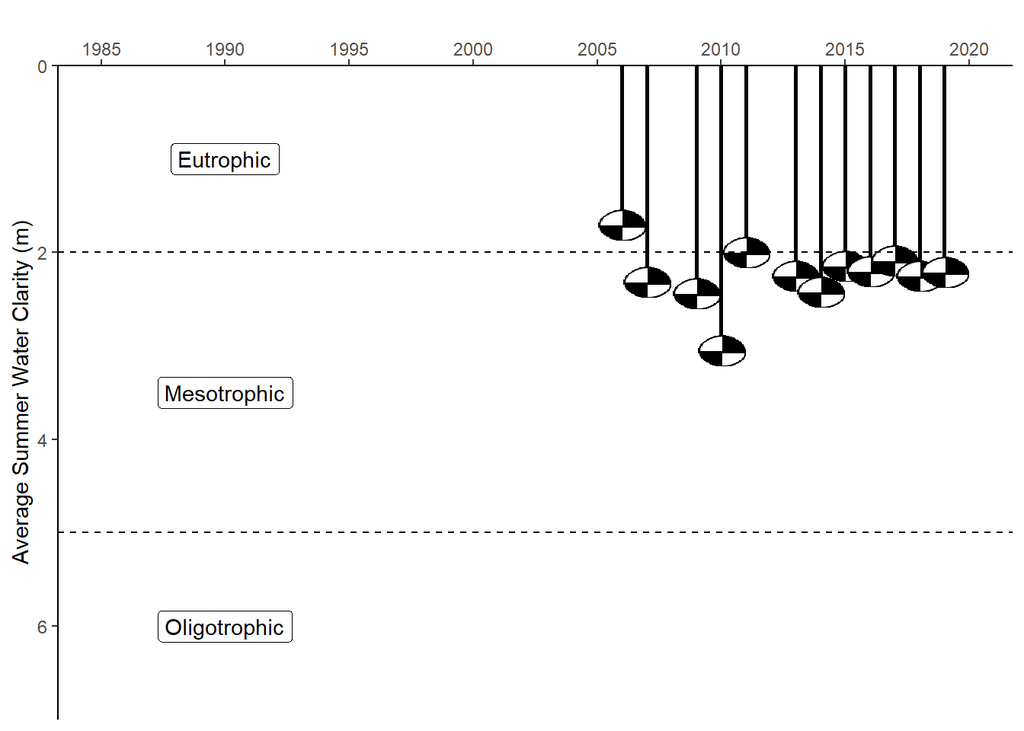

#### Chlorophyll *a*

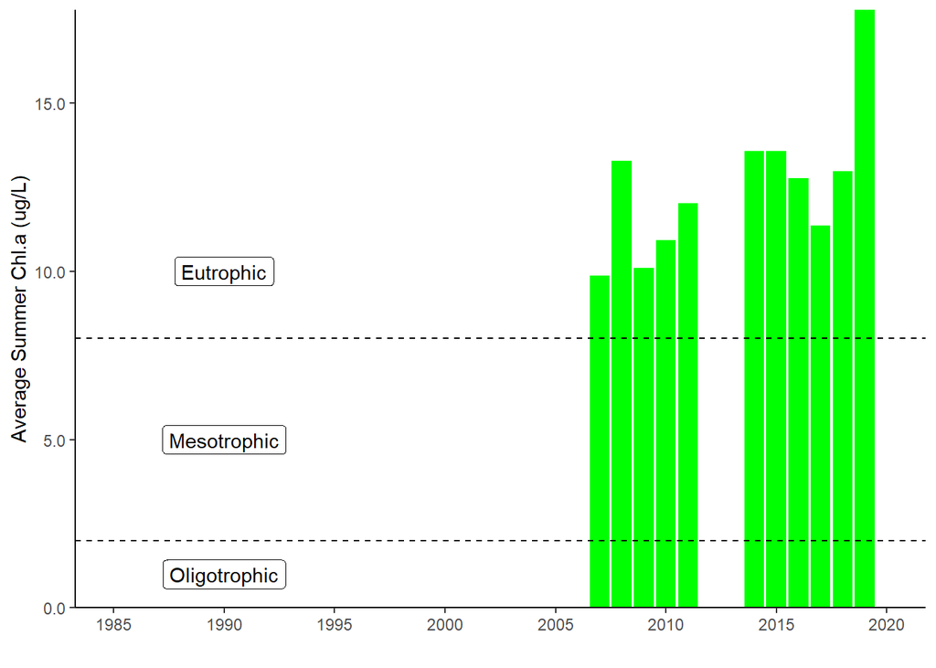

#### Surface and Deep Phosphorus

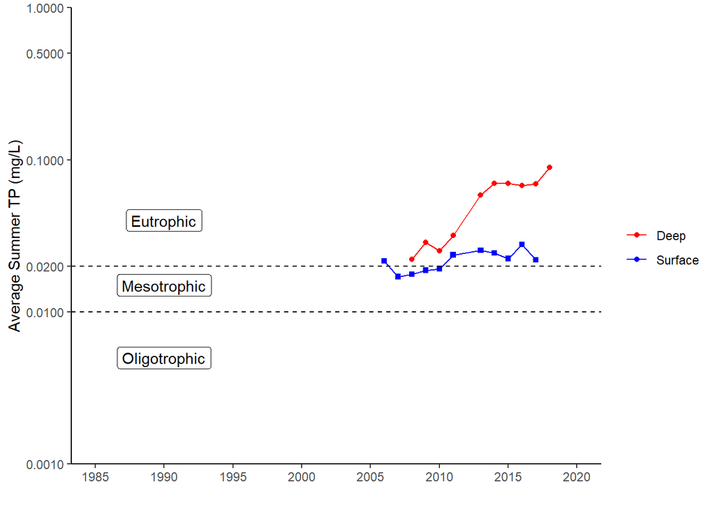

#### Nitrogen

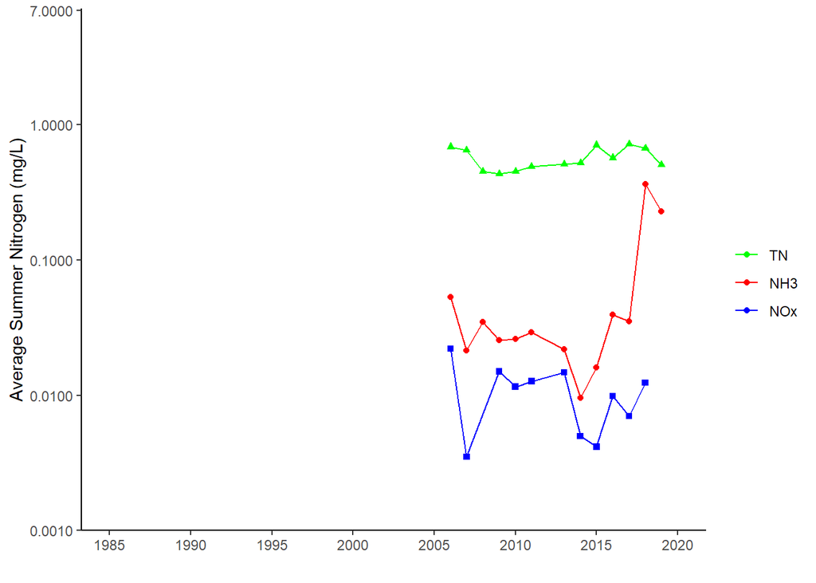

#### TN : TP

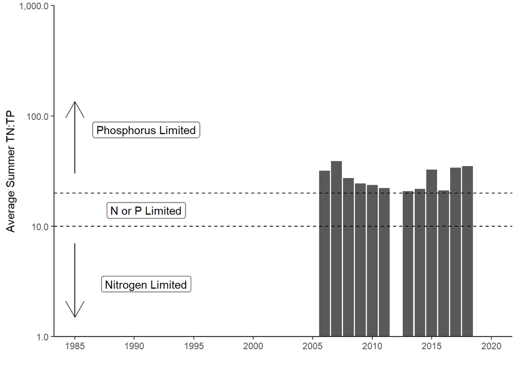

#### pH

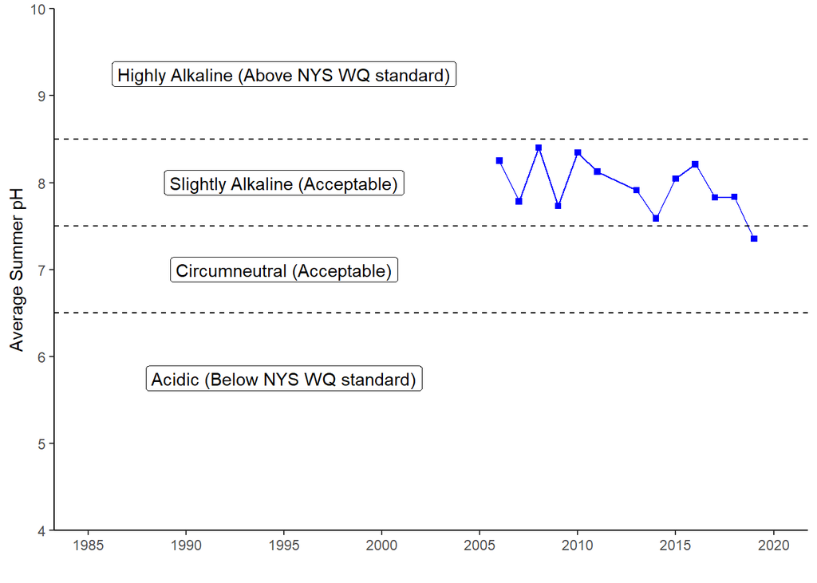

#### Specific Conductance

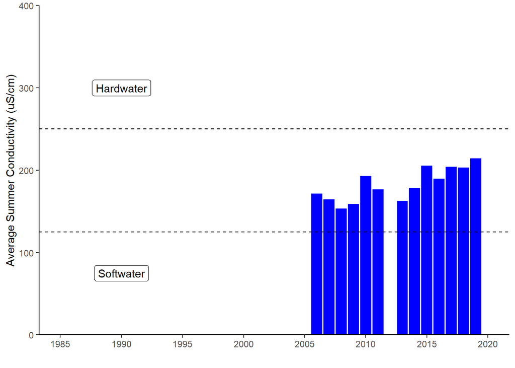

#### Calcium

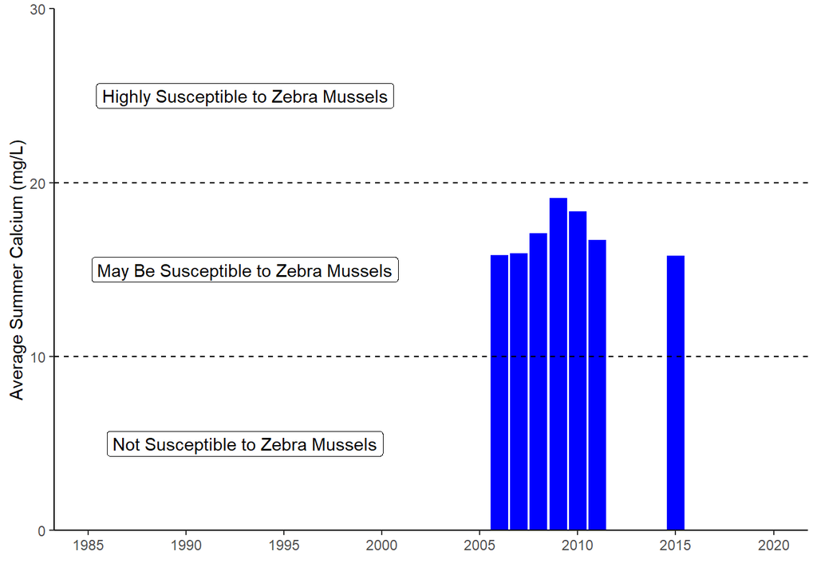

#### Chloride

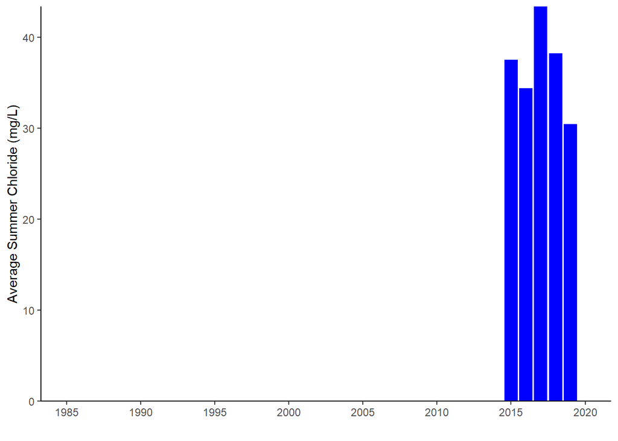

#### Color

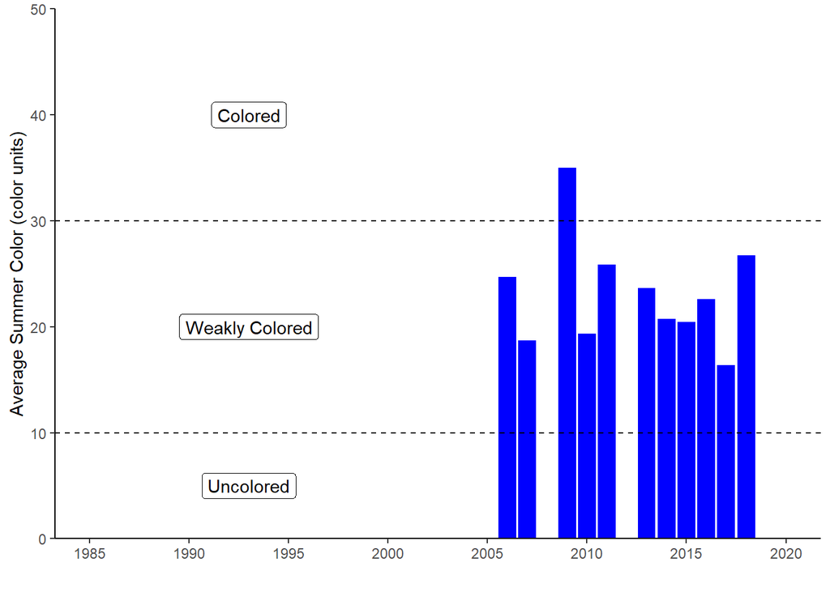